# PSet 4

### 1. `mycars` missing patterns

```r
library(tidyverse)
library(patchwork)
library(janitor)

# Add NAs to mtcars dataset
set.seed(5702)
mycars <- mtcars
mycars[1:25, "gear"] <- NA
mycars[10:20, 3:5] <- NA
for (i in 1:10) mycars[sample(32,1), sample(11,1)] <- NA
```

Missing Values by Column Count

```r
variable.values <- mycars %>%
    gather(key = "key", value = "val") %>%
    mutate(is.missing = is.na(val)) %>%
    group_by(key, is.missing) %>%
    summarise(missing_count = n())
no_missing_values_variable <- variable.values  %>%
  filter(is.missing==F && missing_count == nrow(mycars))
no_missing_values_variable[no_missing_values_variable == nrow(mycars)] <- 0
missing_values_variable <- variable.values %>%
  filter(is.missing==T)
total_set <- rbind(no_missing_values_variable , missing_values_variable ) %>%
  select(-is.missing) %>%
  arrange(desc(missing_count))
```

Code to find and count the missing patterns:

```r
missing_patterns <- data.frame(is.na(mycars)) %>%
  group_by_all() %>%
  count(name = "count", sort = TRUE) %>%
  ungroup()

missing_patterns_converted <- missing_patterns %>%  mutate_all(as.integer) %>%  adorn_totals("col")
missing_patterns_converted
```

```
##  mpg cyl disp hp drat wt qsec vs am gear carb count Total
##    0   0    0  0    0  0    0  0  0    1    0    13    14
##    0   0    1  1    1  0    0  0  0    1    0     7    11
##    0   0    0  0    0  0    0  0  0    0    0     5     5
##    0   0    1  1    1  0    0  0  1    1    0     2     7
##    0   0    0  0    0  0    0  1  0    1    0     1     3
##    0   0    0  1    0  0    0  0  1    0    0     1     3
##    0   0    1  0    0  0    0  0  0    0    0     1     2
##    0   0    1  1    1  0    1  0  0    1    0     1     6
##    0   1    1  1    1  0    0  0  0    1    0     1     6
```

```r
complete_cases_rowno <- which(missing_patterns_converted$count == missing_patterns_converted$Total)
missing_patterns_converted <- missing_patterns_converted %>%
  mutate(fct = ifelse(missing_patterns_converted$count == missing_patterns_converted$Total, 1, 0.5))%>%
  rownames_to_column("id")

missing_dataset <- missing_patterns %>%
    rownames_to_column("id") %>%
    gather(key, value, -id)

missing_dataset <- merge(x = missing_dataset, y = total_set, by = "key", all.x = TRUE)
missing_dataset$factor <- as.factor(missing_dataset$value)
missing_dataset$factor <- as.factor(ifelse(missing_dataset$id == complete_cases_rowno, .5, missing_dataset$factor ))
```

Different Charts

```r
chart1 <- ggplot(total_set) +
  geom_bar(aes(x=reorder(key , -missing_count), y=missing_count), stat = 'identity',fill="lightblue")+theme_bw()+
  labs(x='', y="num rows missing")
```

```r
missing_dataset
```

```
##       key id value missing_count factor
## 1      am  1     0             3      1
## 2      am  2     0             3      1
## 3      am  3     0             3    0.5
## 4      am  4     1             3      2
## 5      am  5     0             3      1
## 6      am  6     1             3      2
## 7      am  7     0             3      1
## 8      am  8     0             3      1
## 9      am  9     0             3      1
## 10   carb  6     0             0      1
## 11   carb  7     0             0      1
## 12   carb  8     0             0      1
## 13   carb  9     0             0      1
## 14   carb  1     0             0      1
```

[output cut: 94 more lines]

```r
chart2 <- ggplot(missing_dataset, aes(x = fct_reorder(key, -missing_count), y = fct_rev(id), fill = factor)) +
  geom_tile(data = subset(missing_dataset , key != "count"), color = "white" , show.legend = FALSE) +
  labs(x='variable', y="missing pattern")+
  scale_fill_manual(values=c("gray45", "gray74" , "plum2")) +
  theme_bw()
```

```r
chart3 <- ggplot(missing_patterns_converted , aes(x = reorder ( id , count) , y = count)) +
  geom_bar(stat = 'identity',  fill="lightblue" , alpha =  (missing_patterns_converted$fct)) + scale_alpha_manual(values = c("0.5" = 0.5 , "1" = 1))+labs(x='', y="row count") + theme_bw()+coord_flip()
```

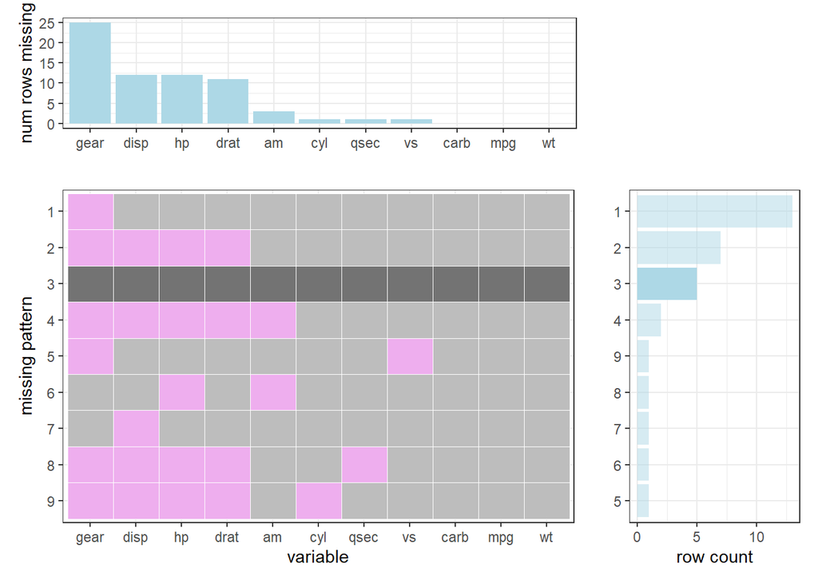

```r
  (chart1 + plot_spacer()+plot_layout(width=c(2.5,1))) / (chart2 + chart3 + plot_layout(widths = c(3,1)))+plot_layout(heights = c(1,3))
```

### 2. Missing value plot function

You either put the function code in a separate `.R` file or include it in the `.Rmd` file.

```r
plot_missing <- function(data , Percentflag) {

variable.values <- data %>%
    gather(key = "key", value = "val") %>%
    mutate(is.missing = is.na(val)) %>%
    group_by(key, is.missing) %>%
    summarise(missing_count = n())


  no_missing_values_variable <- variable.values  %>%
    filter(is.missing==F && missing_count == nrow(data))

  no_missing_values_variable[no_missing_values_variable == nrow(data)] <- 0

  missing_values_variable <- variable.values %>% filter(is.missing==T)

  total_set <- rbind(no_missing_values_variable , missing_values_variable ) %>%
    select(-is.missing) %>% arrange(desc(missing_count))

  if(Percentflag){
    total_set$missing_count <- total_set$missing_count / nrow(data) * 100
  }

  missing_patterns <- data.frame(is.na(data)) %>%
  group_by_all() %>%
  count(name = "count", sort = TRUE) %>%
  ungroup()

missing_patterns_converted <- missing_patterns %>%  mutate_all(as.integer) %>%  adorn_totals("col")
complete_cases_rowno <- which(missing_patterns_converted$count == missing_patterns_converted$Total)
missing_patterns_converted <- missing_patterns_converted %>%
  mutate(fct = ifelse(missing_patterns_converted$count == missing_patterns_converted$Total, 1, 0.5))%>%
  rownames_to_column("id")

  if(Percentflag){
    missing_patterns_converted$count <- missing_patterns_converted$count / nrow(data) * 100
  }

  missing_dataset <- missing_patterns %>%
    rownames_to_column("id") %>%
    gather(key, value, -id)

comp <- which(rowSums(missing_patterns_converted[,'fct'])==1.0)
if (length(comp) == 0) { comp <- 0 }

  missing_dataset <- merge(

    x = missing_dataset, y = total_set, by = "key", all.x = TRUE)
  missing_dataset$factor <- as.factor(missing_dataset$value)

  if (comp != 0) {
  missing_dataset$factor <- as.factor(ifelse(missing_dataset$id == complete_cases_rowno, .5, missing_dataset$factor ))}

  ylevels <- reorder(missing_patterns_converted$id,  missing_patterns_converted$count)
  ylevels
  #missing_dataset$id <- as.factor(missing_dataset$id)
  #missing_dataset <- missing_dataset %>% group_by(id, key,missing_count) %>% mutate (count = count(id))

  #missing_dataset$id <- reorder(missing_dataset$id, missing_dataset$count)






  chart1 <- ggplot(total_set) +
    geom_bar(aes(x=reorder(key , -missing_count), y=missing_count), stat = 'identity',fill="lightblue")+
    labs(x='',y = ifelse(Percentflag == TRUE , "% rows \n missing" ,"num rows \n missing")) +
    theme_bw()+ theme(axis.text.x = element_text(angle = 90, vjust = 0.5, hjust=1))

if (comp != 0) {
  chart2 <- ggplot(missing_dataset,aes(x = fct_reorder(key, - missing_count), y = fct_relevel(id,levels(ylevels)), fill =factor))+
    geom_tile(data = subset(missing_dataset , key != "count"), color = "white" , show.legend = FALSE) +
    labs(x='variable', y="missing pattern")+
    scale_fill_manual(values=c("gray45", "gray74" , "plum2")) +
    theme_bw()+ theme(axis.text.x = element_text(angle = 90, vjust = 0.5, hjust=1))
}else{
      chart2 <- ggplot(missing_dataset,aes(x = fct_reorder(key, - missing_count), y = fct_relevel(id,levels(ylevels)), fill =factor))+
    geom_tile(data = subset(missing_dataset , key != "count"), color = "white" , show.legend = FALSE) +
    labs(x='variable', y="missing pattern")+
    scale_fill_manual(values=c( "gray74" , "plum2")) +
    theme_bw()+ theme(axis.text.x = element_text(angle = 90, vjust = 0.5, hjust=1))

  }

 if (comp != 0) { chart2 <- chart2 + # adjustments due to grid starting at 0,0
    annotate("text",
             x=ncol(missing_patterns)/2,
             y=nrow(missing_patterns)+1-comp,
             label="complete cases")}

  chart3 <- ggplot(missing_patterns_converted , aes(x = reorder ( id , count) , y = count)) +
    geom_bar(stat = 'identity',  fill="lightblue" , alpha =  (missing_patterns_converted$fct))+
    scale_alpha_manual(values = c("0.5" = 0.5 , "1" = 1))+
    labs(x='', y = ifelse(Percentflag == TRUE , "% rows" ,"row count")) +
    coord_flip() +
    theme_bw()

    (chart1 + plot_spacer()+plot_layout(width=c(2.5,1))) / (chart2 + chart3 + plot_layout(widths = c(3,1)))+plot_layout(heights = c(1,3))



}
```

2. Show the output for both options (counts / percent) for the `economics` dataset in the **ggplot2** package. (This is a test to see if your function works if there are no missing values.)

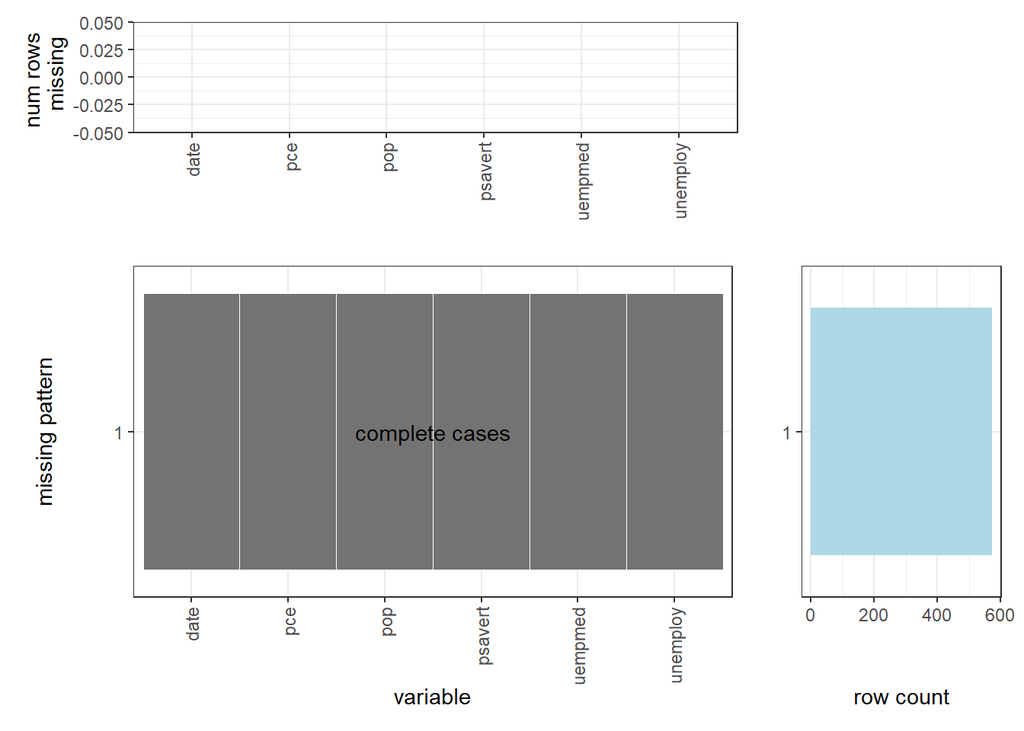

```r
plot_missing(economics, Percentflag  = FALSE)
```

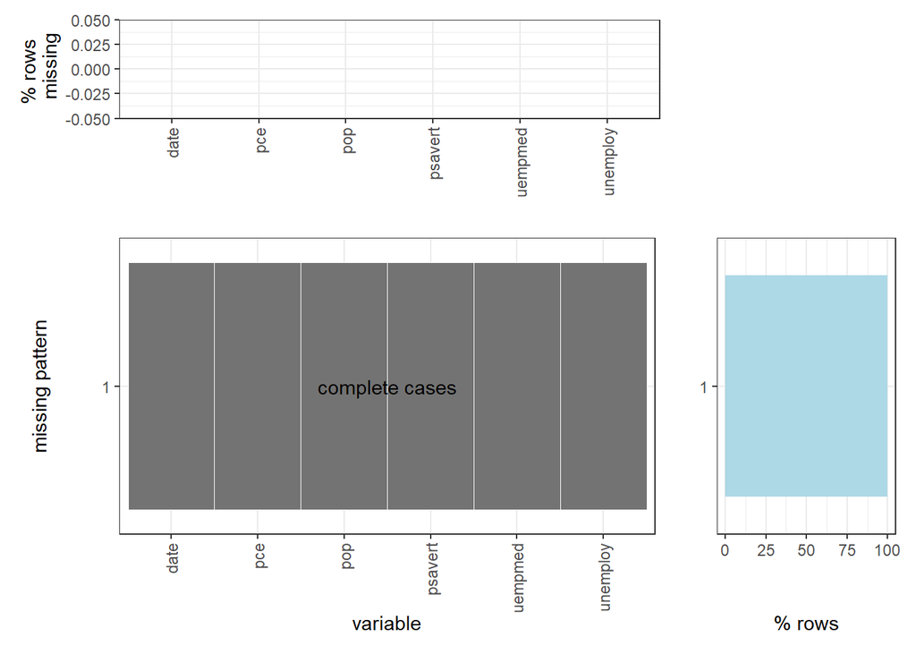

```r
plot_missing(economics, Percentflag  = TRUE)
```

3. Show the output for both options (counts / percent) for the `HollywoodMovies2011` dataset in the **Lock5withR** package. You can shorten the column names so they don’t overlap in the plot.

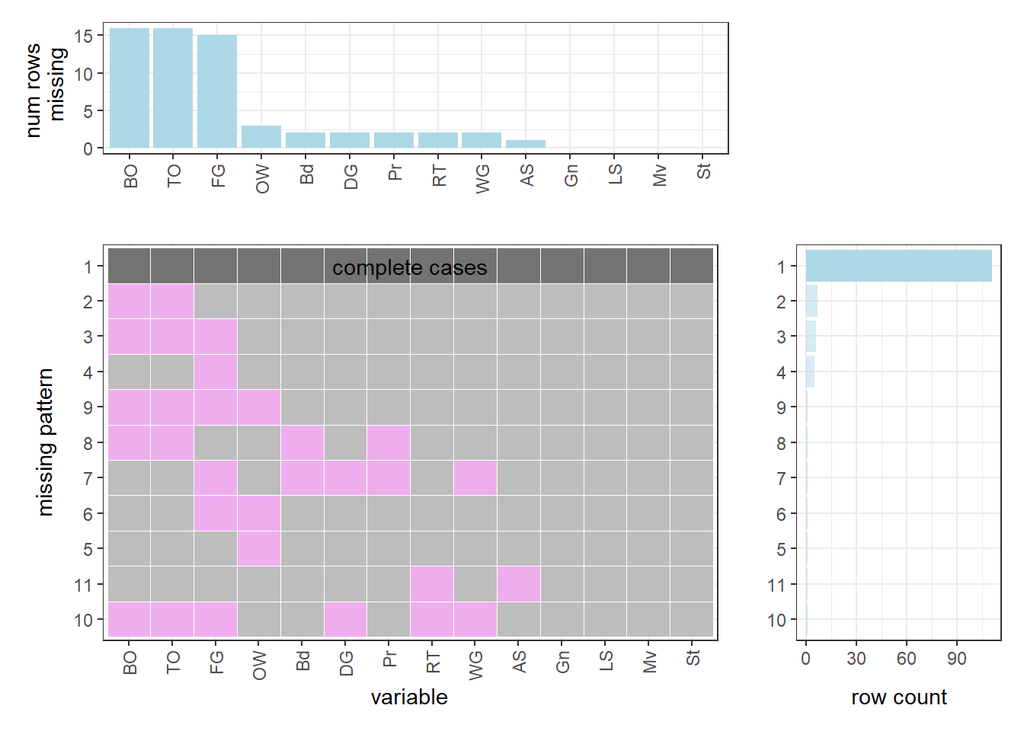

```r
library(Lock5withR)
names(HollywoodMovies2011) <- abbreviate(names(HollywoodMovies2011), minlength=2)
plot_missing(HollywoodMovies2011, Percentflag  = FALSE)
```

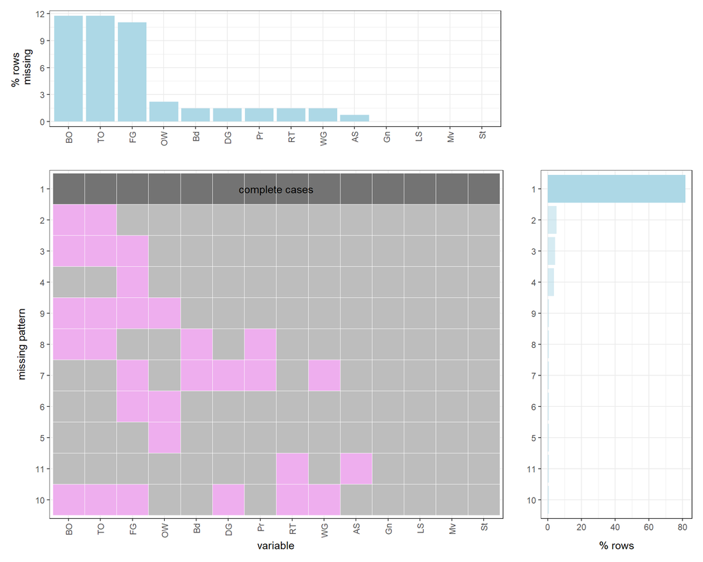

```r
plot_missing(HollywoodMovies2011, Percentflag  = TRUE)
```